# Capstone_Project_Analysis_Report

Jumana Alaarajee

2025-03-10

## Introduction:

In this analysis we explore social media engagement across various social media platforms such as Facebook, Instagram, TikTok and many others. Engagement is defined as the combination of user activity which includes likes, posts, follows and time spent on the application. The objective of this analysis is to determine which social media platform has the best engagement and assess any correlation between user interaction (likes, follows, posts) and time spent.

## Data Upload:

The dataset used for this analysis can be obtained through Kaggle, https://www.kaggle.com/datasets/bhadramohit/social-media-usage-datasetapplications. This dataset takes information from 1000 random users across all social media platforms and provides information regarding time spend on the app, likes, follows, and posts.

```r
data <-read.csv("social_media_usage.csv")
head(data)
```

```
##   User_ID       App Daily_Minutes_Spent Posts_Per_Day Likes_Per_Day
## 1     U_1 Pinterest                 288            16            94
## 2     U_2  Facebook                 192            14           117
## 3     U_3 Instagram                 351            13           120
## 4     U_4    TikTok                  21            20           117
## 5     U_5  LinkedIn                 241            16             9
## 6     U_6   Twitter                 464             3           137
##   Follows_Per_Day
## 1               0
## 2              15
## 3              48
## 4               8
## 5              21
## 6              30
```

## Engagement Calculation:

We define engagement as a ratio of user activity (posts, likes, and follows) to the time spent on the platform. The formula for calculating engagement is:

Engagement = (Posts Per Day + Likes Per Day + Follows Per Day) / Daily Minutes Spent

This provides us with a normalized measure of user activity. We create a new column, engagement, to store this calculated value for each user.

## Engagement Barplot Visualization:

Next, we visualize the average engagement per social media platform. The bar plot below shows the average engagement across different platforms, helping us identify which platform has the highest average user engagement.

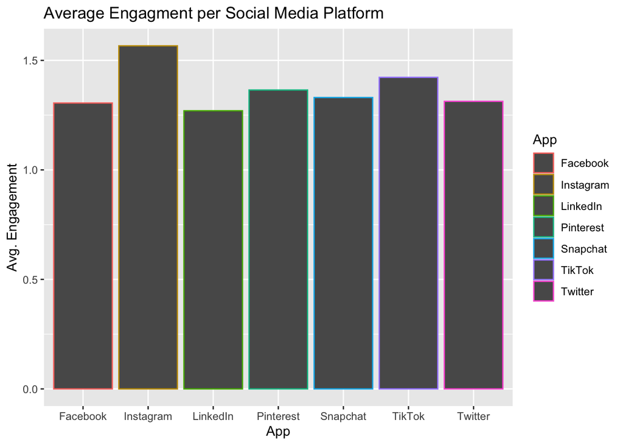

## Correlation Analysis:

To further understand the relationships between user behavior and engagement, we calculate the correlations between various factors: posts per day, likes per day, follows per day, and daily minutes spent. These correlations help us understand the strength of the relationship between different user interactions and time spent on the platform.

```r
cor(data$Posts_Per_Day,data$engagement)
```

```
## [1] 0.05808234
```

```r
cor(data$Likes_Per_Day,data$engagement)
```

```
## [1] 0.1946494
```

```r
cor(data$Follows_Per_Day,data$engagement)
```

```
## [1] 0.08597245
```

```r
cor(data$Daily_Minutes_Spent,data$engagement)
```

```
## [1] -0.4595293
```

## Correlation between other Attributes

```r
cor(data$Posts_Per_Day,data$Likes_Per_Day)
```

```
## [1] 0.0168925
```

```r
cor(data$Posts_Per_Day,data$Follows_Per_Day)
```

```
## [1] 0.01811347
```

```r
cor(data$Posts_Per_Day,data$Daily_Minutes_Spent)
```

```
## [1] -0.02396778
```

```r
cor(data$Daily_Minutes_Spent, data$Likes_Per_Day)
```

```
## [1] 0.01354504
```

```r
cor(data$Daily_Minutes_Spent, data$Follows_Per_Day)
```

```
## [1] 0.03752094
```

```r
cor(data$Likes_Per_Day, data$Follows_Per_Day)
```

```
## [1] -0.01747591
```

## Analysis Findings:

Engagement and User Interactions: There is no significant correlation between engagement and individual user interactions such as posts, likes, or follows. This suggests that engagement may not be entirely dependent on these factors and can be influenced by other factors not mentioned, such as user preferences or content quality.

Time Spent vs User Interactions: Similarly, the correlation between time spent and user interactions (likes, follows, posts) is also weak. This indicates that users who spend more time on the platform do not necessarily engage more in terms of likes, follows, or posts.

Overall Trends: The correlations between the different user interactions (posts, likes, follows) are relatively weak, indicating that these factors may be independent of each other.

## Conclusion:

Average Engagement: Different platforms have varying levels of average engagement, with certain platforms showing higher levels of user interaction compared to others.We find that Instagram and TikTok exhibit the two highest average user engagement. This could be explained by the fact that these platforms are particularly popular among younger generations, who are typically more active on social media. Understanding these trends can help businesses or content creators identify platforms with the highest user engagement, aiding in more effective outreach and audience targeting.

Correlations: The lack of significant correlations between engagement and user behavior metrics (posts, likes, follows) implies that these factors do not always lead to higher engagement. Additionally, the weak correlations between time spent and user interactions suggest that other factors might be influencing engagement.